# Investment-game (bandit) pilot (Prolific, Nov 2026)

Democrats invest $100,000 in $1,000 clicks in Riverton (R) or Lakewood (D) after chatting with a Republican persona bot or a cats-vs-dogs control bot

Published

November 7, 2026

```r
library(tidyverse)
library(jsonlite)
library(knitr)
knitr::opts_chunk$set(dpi = 150, fig.width = 8, fig.height = 4.5)
options(knitr.kable.NA = "–")
theme_set(theme_minimal(base_size = 12) + theme(panel.grid.minor = element_blank()))

PROC <- "data/processed"
pull_log <- fromJSON("data/pull_log.json")
UNIT <- 1000; N_INVEST <- 100; MEAN_R <- 1.35; MEAN_D <- 1.00
COND_COLORS <- c(control = "#9ca3af", treatment = "#2563eb")
COND_LABELS <- c(control = "Control (cats-vs-dogs bot)", treatment = "Treatment (Republican persona bot)")
se <- function(x) sd(x, na.rm = TRUE) / sqrt(sum(!is.na(x)))
fmt <- function(x, d = 2) formatC(x, format = "f", digits = d)

parts <- read_csv(file.path(PROC, "participants.csv"), show_col_types = FALSE) |>
  mutate(across(c(started_at, completed_at, game_finished_at, starts_with("ts_")), ymd_hms),
         completed = !is.na(completed_at))
inv <- read_csv(file.path(PROC, "investments.csv"), show_col_types = FALSE) |>
  mutate(R = county == "R", saved_at = ymd_hms(saved_at))
screen <- read_csv(file.path(PROC, "screenouts.csv"), show_col_types = FALSE)
errors <- read_csv(file.path(PROC, "client_errors.csv"), show_col_types = FALSE)
chats <- read_csv(file.path(PROC, "chat_messages.csv"), show_col_types = FALSE)
done <- parts |> filter(completed, n_investments_saved == N_INVEST)
n_by <- count(done, condition) |> deframe()
```

## Snapshot

Data pulled 2026-11-07 18:13 ET from MongoDB `twins-bandit-game` and the chatbot’s Postgres log (Prolific study 6aef9994ac7e235b0696943f; app tag `v3.0.0-bandit-pilot`).

**Design.** Democrats who pass screening chat for 5 minutes with a Republican persona bot (treatment) or a bot that debates cats vs dogs (control). They then invest a $100,000 budget in 100 clicks of $1,000. Each click goes to Riverton County (Republican-leaning) or Lakewood County (Democratic-leaning) and shows the money that came back right away. A $1,000 investment brings back $1,350 on average in Riverton and $1,000 in Lakewood, with large luck: one return’s SD is 61% (Riverton) and 71% (Lakewood) of its mean. Sending every click to Riverton is best. The k-th treated and k-th control participant face the same sequence of returns. The bonus maps money back from $100,000 (expected if every click goes to Lakewood) to $135,000 (every click to Riverton) onto $0 to $1.00.

This pilot has 19 complete participants (10 treatment, 9 control). Every condition comparison below is descriptive; its purpose is to check that the game works and to size the main study.

## 1. Flow, timing and data quality

```r
tibble(
  Step = c("Screened out before assignment", "Assigned", "Completed (all 100 clicks and demographics)"),
  Total = c(nrow(screen), nrow(parts), nrow(done)),
  Treatment = c(NA, sum(parts$condition == "treatment"), n_by["treatment"]),
  Control = c(NA, sum(parts$condition == "control"), n_by["control"])
) |> kable(caption = "Participant flow (counts of people).")
```

Participant flow (counts of people).

| Step | Total | Treatment | Control |
| --- | --- | --- | --- |
| Screened out before assignment | 1 | – | – |
| Assigned | 19 | 10 | 9 |
| Completed (all 100 clicks and demographics) | 19 | 10 | 9 |

```r
# Screen timestamps come from the participant's browser clock; drop people whose clock is off by more
# than 5 minutes (browser time at assignment vs the server's assignment time).
times <- done |>
  mutate(skew_min = abs(as.numeric(difftime(ts_chat_intro, started_at, units = "mins")))) |>
  filter(skew_min < 5) |>
  mutate(total_min = as.numeric(difftime(completed_at, ts_attention_math, units = "mins")),
         game_min = as.numeric(difftime(game_finished_at, ts_game, units = "mins")),
         tut_min = as.numeric(difftime(ts_game, ts_game_tutorial, units = "mins")))
```

Median time from the consent click to the end was 11.1 minutes (range 7.6–17.3); pay covers 10 minutes. Timing excludes 2 participants whose browser clocks were off by hours. The instructions took a median of 1.6 minutes and the 100 clicks 2.6 minutes.

```r
inv_chk <- inv |> group_by(participant_id) |>
  summarise(gaps = !all(sort(n) == seq_along(n)), .groups = "drop")
tibble(
  Check = c("Completers with fewer than 100 saved clicks", "Clicks saved out of order or with gaps",
            "Clicks where the browser's money back differs from the server's",
            "Completers whose browser bonus differs from the server bonus (> 1¢)",
            "Client errors logged", "Treated participants not served the Republican bot",
            "Control participants not served the cats-vs-dogs bot"),
  Problems = c(sum(done$n_investments_saved < N_INVEST), sum(inv_chk$gaps), sum(done$n_back_mismatch),
               sum(abs(done$game_bonus - done$game_bonus_client) > 0.011, na.rm = TRUE), nrow(errors),
               sum(!parts$participant_id[parts$condition == "treatment"] %in%
                     chats$participant_id[chats$bot_prompt %in% "republican_persona"]),
               sum(!parts$participant_id[parts$condition == "control"] %in%
                     chats$participant_id[chats$bot_prompt %in% "cats_dogs"]))
) |> kable(caption = "Integrity checks (0 means clean).")
```

Integrity checks (0 means clean).

| Check | Problems |
| --- | --- |
| Completers with fewer than 100 saved clicks | 0 |
| Clicks saved out of order or with gaps | 0 |
| Clicks where the browser’s money back differs from the server’s | 0 |
| Completers whose browser bonus differs from the server bonus (> 1¢) | 0 |
| Client errors logged | 0 |
| Treated participants not served the Republican bot | 0 |
| Control participants not served the cats-vs-dogs bot | 0 |

## 2. Learning across the game

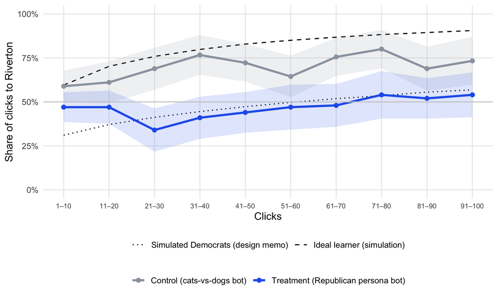

```r
blocks <- inv |> filter(participant_id %in% done$participant_id) |>
  mutate(block = (n - 1) %/% 10 + 1) |>
  group_by(participant_id, condition, block) |> summarise(share_R = mean(R), .groups = "drop")
sim <- read_csv("../09_bandit_prototype/output/curves.csv", show_col_types = FALSE) |>
  filter(ratio == 1.35, n0_med == 20, group %in% c("Control", "Ideal learner")) |>
  mutate(block = (visit - 1) %/% 10 + 1) |> group_by(group, block) |> summarise(p = mean(p_r), .groups = "drop")
blocks |> group_by(condition, block) |> summarise(m = mean(share_R), s = se(share_R), .groups = "drop") |>
  ggplot(aes(block, m, colour = condition)) +
  geom_line(data = sim, aes(block, p, linetype = group), inherit.aes = FALSE, colour = "black", linewidth = 0.6) +
  geom_ribbon(aes(ymin = m - s, ymax = m + s, fill = condition), alpha = 0.15, colour = NA) +
  geom_line(linewidth = 1.2) + geom_point(size = 2) +
  geom_hline(yintercept = 0.5, colour = "grey80") +
  scale_colour_manual(values = COND_COLORS, labels = COND_LABELS, name = NULL) +
  scale_fill_manual(values = COND_COLORS, guide = "none") +
  scale_linetype_manual(values = c(Control = "dotted", `Ideal learner` = "dashed"),
                        labels = c(Control = "Simulated Democrats (design memo)", `Ideal learner` = "Ideal learner (simulation)"), name = NULL) +
  scale_x_continuous(breaks = 1:10, labels = paste0(seq(1, 91, 10), "–", seq(10, 100, 10))) +
  scale_y_continuous(limits = c(0, 1), labels = scales::percent) +
  labs(x = "Clicks", y = "Share of clicks to Riverton") +
  theme(legend.position = "bottom", legend.box = "vertical", axis.text.x = element_text(size = 8))
```

*Figure 1. Share of clicks sent to Riverton in each block of 10 clicks, by condition (mean ± 1 SE across participants). Black lines come from the design simulation (`studies/09_bandit_prototype`, Riverton 1.35×, prior worth about 20 clicks): dotted, simulated Democrats who start out believing Lakewood is better; dashed, an ideal learner.*

```r
pooled <- blocks |> group_by(block) |> summarise(m = mean(share_R), .groups = "drop")
better <- count(done, pilot_better_county)
```

People learned, but slowly. Across both conditions the Riverton share rose from 53% in clicks 1–10 to 63% in clicks 91–100; an ideal learner reaches about 90%. After the game, 13 of 19 people said Riverton brought back more money per $1,000.

## 3. Treatment vs control

```r
per <- inv |> filter(participant_id %in% done$participant_id) |>
  group_by(participant_id, condition) |>
  summarise(first_R = as.numeric(R[n == 1]), share_1_10 = mean(R[n <= 10]), share_all = mean(R),
            share_91_100 = mean(R[n > 90]), .groups = "drop") |>
  left_join(select(done, participant_id, game_bonus), by = "participant_id")
outcomes <- c(first_R = "First click to Riverton (before any feedback)", share_1_10 = "Riverton share, clicks 1–10",
              share_all = "Riverton share, all 100 clicks", share_91_100 = "Riverton share, clicks 91–100",
              game_bonus = "Bonus ($)")
tvc <- map_dfr(names(outcomes), function(o) {
  t <- per[[o]][per$condition == "treatment"]; c <- per[[o]][per$condition == "control"]
  tt <- t.test(t, c)
  sp <- sqrt(((length(t) - 1) * var(t) + (length(c) - 1) * var(c)) / (length(t) + length(c) - 2))
  tibble(Outcome = outcomes[o], `Treatment mean (SE)` = paste0(fmt(mean(t)), " (", fmt(se(t)), ")"),
         `Control mean (SE)` = paste0(fmt(mean(c)), " (", fmt(se(c)), ")"),
         `Diff (T − C)` = fmt(mean(t) - mean(c)), `95% CI` = paste0("[", fmt(tt$conf.int[1]), ", ", fmt(tt$conf.int[2]), "]"),
         p = fmt(tt$p.value), d = fmt((mean(t) - mean(c)) / sp), sd_pooled = sp)
})
tvc |> select(-sd_pooled) |> kable(caption = "Treatment minus control, one value per participant. Welch t-test CIs; Cohen's d uses the pooled SD.")
```

Treatment minus control, one value per participant. Welch t-test CIs; Cohen’s d uses the pooled SD.

| Outcome | Treatment mean (SE) | Control mean (SE) | Diff (T − C) | 95% CI | p | d |
| --- | --- | --- | --- | --- | --- | --- |
| First click to Riverton (before any feedback) | 0.30 (0.15) | 0.33 (0.17) | -0.03 | [-0.51, 0.44] | 0.88 | -0.07 |
| Riverton share, clicks 1–10 | 0.47 (0.08) | 0.59 (0.09) | -0.12 | [-0.38, 0.14] | 0.35 | -0.45 |
| Riverton share, all 100 clicks | 0.47 (0.08) | 0.70 (0.10) | -0.23 | [-0.50, 0.04] | 0.09 | -0.84 |
| Riverton share, clicks 91–100 | 0.54 (0.13) | 0.73 (0.14) | -0.19 | [-0.59, 0.20] | 0.32 | -0.48 |
| Bonus ($) | 0.54 (0.09) | 0.68 (0.09) | -0.14 | [-0.40, 0.12] | 0.27 | -0.52 |

```r
d_all <- tvc$d[tvc$Outcome == outcomes["share_all"]]
diff_all <- as.numeric(tvc$`Diff (T − C)`[tvc$Outcome == outcomes["share_all"]])
```

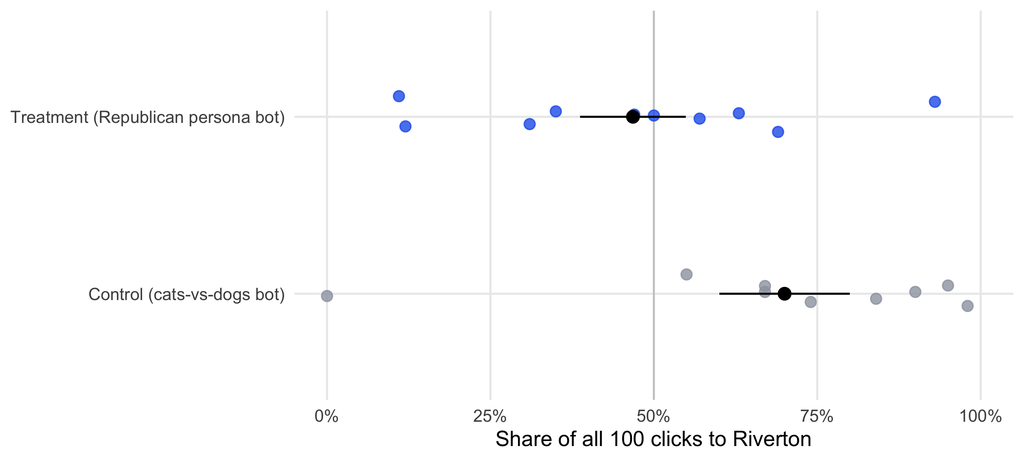

```r
per |> mutate(condition = factor(condition, levels = c("control", "treatment"))) |>
  ggplot(aes(share_all, condition, colour = condition)) +
  geom_vline(xintercept = 0.5, colour = "grey80") +
  geom_jitter(height = 0.12, width = 0, size = 2.5, alpha = 0.8) +
  stat_summary(fun.data = mean_se, colour = "black", geom = "pointrange") +
  scale_colour_manual(values = COND_COLORS, guide = "none") +
  scale_y_discrete(labels = COND_LABELS) + scale_x_continuous(labels = scales::percent, limits = c(0, 1)) +
  labs(x = "Share of all 100 clicks to Riverton", y = NULL)
```

*Figure 2. Each dot is one participant’s share of clicks to Riverton; black points are condition means ± 1 SE.*

## 4. Response to feedback

```r
fb <- inv |> filter(participant_id %in% done$participant_id) |> arrange(participant_id, n) |>
  group_by(participant_id) |>
  mutate(next_county = lead(county), good = back >= UNIT) |> ungroup() |> filter(!is.na(next_county)) |>
  mutate(stay = next_county == county)
fb_tab <- fb |> group_by(participant_id, condition, county, good) |> summarise(stay = mean(stay), .groups = "drop") |>
  group_by(condition, County = if_else(county == "R", "Riverton", "Lakewood"),
           `Last return` = if_else(good, "$1,000 or more", "under $1,000")) |>
  summarise(`P(stay), mean (SE)` = paste0(fmt(mean(stay)), " (", fmt(se(stay)), ")"), People = n(), .groups = "drop")
kable(fb_tab, caption = "Probability of clicking the same county again after a good (≥ $1,000) or bad (< $1,000) return; mean across participants.")
```

Probability of clicking the same county again after a good (≥ $1,000) or bad (< $1,000) return; mean across participants.

| condition | County | Last return | P(stay), mean (SE) | People |
| --- | --- | --- | --- | --- |
| control | Lakewood | $1,000 or more | 0.78 (0.11) | 7 |
| control | Lakewood | under $1,000 | 0.55 (0.11) | 9 |
| control | Riverton | $1,000 or more | 0.93 (0.03) | 8 |
| control | Riverton | under $1,000 | 0.82 (0.06) | 8 |
| treatment | Lakewood | $1,000 or more | 0.83 (0.06) | 10 |
| treatment | Lakewood | under $1,000 | 0.70 (0.09) | 10 |
| treatment | Riverton | $1,000 or more | 0.81 (0.06) | 10 |
| treatment | Riverton | under $1,000 | 0.59 (0.12) | 10 |

People respond to feedback: they stay with a county more often after a good return than after a bad one, in both counties and both conditions. Table 4 is the raw material for the learning model in the main study (separate learning rates for good and bad news from each county).

## 5. Comprehension and self-reports

```r
done |> count(`Attempts at the quick check` = tutorial_check_attempts) |>
  kable(caption = "Attempts needed to pass the 2-question check before the game.")
```

Attempts needed to pass the 2-question check before the game.

| Attempts at the quick check | n |
| --- | --- |
| 1 | 6 |
| 2 | 10 |
| 3 | 3 |

```r
done |> count(condition, `Which county brought back more per $1,000?` = pilot_better_county) |>
  pivot_wider(names_from = condition, values_from = n, values_fill = 0) |>
  kable(caption = "Post-game question, by condition.")
```

Post-game question, by condition.

| Which county brought back more per $1,000? | control | treatment |
| --- | --- | --- |
| Lakewood | 1 | 3 |
| Riverton | 8 | 5 |
| About the same | 0 | 2 |

```r
done |> left_join(select(per, participant_id, share_all), by = "participant_id") |>
  arrange(condition, share_all) |>
  transmute(Condition = condition, `Riverton share` = scales::percent(share_all, 1),
            `How did you decide where to invest?` = coalesce(pilot_decision_strategy, "")) |>
  kable(caption = "Open-text strategies (optional), sorted by condition and Riverton share.")
```

Open-text strategies (optional), sorted by condition and Riverton share.

| Condition | Riverton share | How did you decide where to invest? |
| --- | --- | --- |
| control | 0% |  |
| control | 55% |  |
| control | 67% | It seemed that Riverton produced a profit more consistently, so I focused the majority of my investment there. |
| control | 67% | I started with a small sample from each and then kind of went back and forth til I compared a larger sample. At that point Riverton was or had been the better option so I mostly stuck with it the rest… |
| control | 74% |  |
| control | 84% | I compared the returns of each past investment and chose the county that consistently provided a higher payout per $1,000 invested to maximize my total profit. |
| control | 90% |  |
| control | 95% |  |
| control | 98% |  |
| treatment | 11% |  |
| treatment | 12% | I went with the deomcrats |
| treatment | 31% | if i was making a profit I stuck with it for a while |
| treatment | 35% | I thought Lakewood was better at first but Riverton gave me bigger bonuses of 4000 at times. Also at the end screen I invested less in Riverton but it brought me back overall more profit than Lakewood… |
| treatment | 47% | I tried to find a rhythm of investing in each county to maximize profit. |
| treatment | 50% | I tired to be fair |
| treatment | 57% | Tried to follow the trend |
| treatment | 63% | I tried clicking on one. If it returned a low amount, I tried the other. When the other returned a low amount, I went back to the other one, and so on like that. |
| treatment | 69% |  |
| treatment | 93% | choose first 5 investments in each county and look for potential |

## 6. Chat content

```r
user_chats <- chats |> filter(!is_system_prompt) |> inner_join(select(done, participant_id, condition), by = "participant_id")
chat_sum <- user_chats |>
  mutate(text = str_to_lower(paste(coalesce(message, ""), coalesce(response, ""))),
         user_words = str_count(coalesce(message, ""), "\\S+")) |>
  group_by(participant_id, condition) |>
  summarise(msgs = n(), user_words = sum(user_words),
            solar = any(str_detect(text, "solar|panel")), energy = any(str_detect(text, "energy|electric|climate|environment")),
            .groups = "drop")
chat_sum |> group_by(Condition = condition) |>
  summarise(People = n(), `Messages, mean` = fmt(mean(msgs), 1), `Words typed, mean` = fmt(mean(user_words), 0),
            `Mentioned solar or panels` = sum(solar), `Mentioned energy, climate or environment` = sum(energy)) |>
  kable(caption = "Chat engagement and topics (participant messages and bot replies).")
```

Chat engagement and topics (participant messages and bot replies).

| Condition | People | Messages, mean | Words typed, mean | Mentioned solar or panels | Mentioned energy, climate or environment |
| --- | --- | --- | --- | --- | --- |
| control | 9 | 6.0 | 70 | 0 | 2 |
| treatment | 10 | 9.6 | 104 | 2 | 4 |

The treatment chat rarely reaches the product: only 2 of 10 treated participants’ chats mention solar or panels. The persona prompt is a generic Republican consumer, and nothing in the flow points the conversation at solar.

## 7. Sizing the main study

```r
sd_all <- tvc$sd_pooled[tvc$Outcome == outcomes["share_all"]]
sd_10 <- tvc$sd_pooled[tvc$Outcome == outcomes["share_1_10"]]
n_for <- function(d) ceiling(power.t.test(delta = d, power = 0.8)$n)
tibble(`Effect (Cohen's d)` = c(0.2, 0.3, 0.4, 0.5)) |>
  mutate(`People per condition (80% power, two-sided α = .05)` = map_int(`Effect (Cohen's d)`, n_for),
         `Same effect in Riverton share, all clicks (points)` = round(100 * `Effect (Cohen's d)` * sd_all, 1),
         `Same effect in Riverton share, clicks 1–10 (points)` = round(100 * `Effect (Cohen's d)` * sd_10, 1)) |>
  kable(caption = "Sample size per condition by effect size, with each d translated into percentage points of Riverton share using this pilot's pooled SDs.")
```

Sample size per condition by effect size, with each d translated into percentage points of Riverton share using this pilot’s pooled SDs.

| Effect (Cohen’s d) | People per condition (80% power, two-sided α = .05) | Same effect in Riverton share, all clicks (points) | Same effect in Riverton share, clicks 1–10 (points) |
| --- | --- | --- | --- |
| 0.2 | 394 | 5.5 | 5.3 |
| 0.3 | 176 | 8.3 | 8.0 |
| 0.4 | 100 | 11.1 | 10.7 |
| 0.5 | 64 | 13.9 | 13.3 |

The pooled SD of the all-clicks Riverton share is 28 points, so a 10-point treatment effect is d ≈ 0.36 and needs about 122 people per condition.